# Lab 6 Convolutional Network Architectures —— CIFAR-10

47491968 Yuankai Liu  
47511663 Jianing Zhao  
47564911 Yang Peng

# 1.Preparation

In lab 6, we will use CIFAR-10 image dataset. The CIFAR-10 dataset consists of 60000 32x32 colour images in 10 classes, with 6000 images per class. There are 50000 training images and 10000 test images.

Because of the consideration of time consumption, we extracted a sample of 5000 images, and each class have 500 images. The class names are as below.

- airplane
- automobile
- bird
- cat
- deer
- dog
- frog
- horse
- ship
- truck

## 1.1 Evaluation Metrics and Preprocessing

Genarally, We use accuracy, precision, recall, f1-score, ROC-AUC to evalate the model in binary classification problems. For multi-classification problems, Precision, Recall, F1, and ROC-AUC should be calculated separately for each class, and integrated as a model evaluation index.

**Accuracy**: It is the most common and basic evaluation metric.

**Precision**: It is the proportion of "true" samples judged by all systems that is truly true, that is, TP/(TP+FP).

**Recall**: It is the proportion of “true” that is judged to be TP/(TP+FN) in all samples that are truly true.

**F1-score**: The metric designed to comprehensively consider the precision and recall.

**ROC-AUC**: It is the curve of TP vs FP.

In this lab, our dataset is about the 10 class of image, so some of metrics seems not very meamingful for us and we finally decided to use accuracy and ROC to evaluate our model. The reasons are as follows.

We think this kind of specific image classification indeed has some application scenarios. For instance, predicting the category of the imput image by the network, it might be used to associate with a given search term and improve on the effectiveness of the search engine. Given the analysis above of our business case, we can know what we are concern about. Because we are just measuring the ability of the our CNN to detect specific objects in images, each class has the eqaul importance and we don't particularly care about any class over another, so false classifications don't weigh more or less.

When it comes to the comparison, we will be using the ROC to see which model has the better performance, because it is clear and intuitive, and it is also required in the assignment.

```python
import keras
from keras.models import Sequential
from keras.layers import Reshape
from keras.layers import Dense, Dropout, Activation, Flatten
from keras.layers import Conv2D, MaxPooling2D
from keras.preprocessing.image import ImageDataGenerator
from keras.callbacks import EarlyStopping
from keras.regularizers import l2
from keras.layers import average
from keras.models import Input, Model
from keras.datasets import cifar10
from sklearn.model_selection import StratifiedKFold
%matplotlib inline
```

```python
from sklearn import metrics as mt
from matplotlib import pyplot as plt
from skimage.io import imshow
import seaborn as sns
```

```python
def summarize_net(net, X_test, y_test, title_text=''):
    plt.figure(figsize=(15,5))
    yhat = np.argmax(net.predict(X_test), axis=1)
    acc = mt.accuracy_score(y_test,yhat)
    cm = mt.confusion_matrix(y_test,yhat)
    cm = cm/np.sum(cm,axis=1)[:,np.newaxis]
    sns.heatmap(cm, annot=True, fmt='.2f')
    plt.title(title_text+'{:.4f}'.format(acc))
```

```python
NUM_CLASSES = 10
img_wh=32
class_name = {
    0: 'airplane',
    1: 'automobile',
    2: 'bird',
    3: 'cat',
    4: 'deer',
    5: 'dog',
    6: 'frog',
    7: 'horse',
    8: 'ship',
    9: 'truck',
}
```

```python
(X_train, y_train), (X_test, y_test) = cifar10.load_data()
X_train.shape
```

```
(50000, 32, 32, 3)
```

```python
# a helper plotting function
def plot_gallery(images, titles, h, w, classname,n_row=3, n_col=6,):
    """Helper function to plot a gallery of portraits"""
    plt.figure(figsize=(1.7 * n_col, 2.3 * n_row))
    for i in range(n_row * n_col):
        plt.subplot(n_row, n_col, i + 1)

        # this line is to get the images to display properly.
        # Due to the way the data is stored, more has to be done on the data than the basic stuff in the example notebooks.
        # rot90(image, 1 rotation, (1,0)) does a 90 degree clockwise rotation
        # images[i].reshape((3,h,w)).T splits the image into its proper channels from its flattened form
        plt.imshow((images[i]))
        plt.title(classname[titles[i][0]], size=12)
        plt.xticks(())
        plt.yticks(())
```

Let us have a look of these pictures before we begin making models.

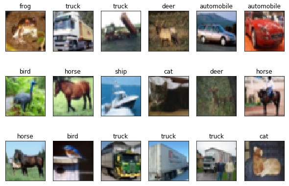

```python
plot_gallery(X_train, y_train, 32, 32,class_name)
```

## 1.2 Training/Testing Split and Cross validation method

In addition to deciding on an evaluation metric that is more appropriate for our business use case, we must also determine the best method by which to divide our data into training and testing splits. Our dataset are 5000 images.

First of all, because of the existence of initial test images, we will be using these 10,000 samples as test set. The testing set will be used for the our model and MLP model to compare the performance.

Then we need to split our 5000 images into training and validation, and the process of splits are stratified. 10 folds is a common number of folds that gets used in cross validation techniques, but we found that the training time of each CNN model is greatly increased relative to our previous work. Cross validation is a good method to improve the performace of model especially in small dataset, the more bigger dataset has the less reliance of cross validation. In the cases of time and the size of our dataset, we would want to use a stratified 2-fold cross validation to help us get better performance of our model.

we will be applying cross validation in our modeling part.

```python
X_train = X_train.astype('float32')
X_test = X_test.astype('float32')
X_train /= 255
X_test /= 255
```

```python
y_train_ohe = to_categorical(y_train, NUM_CLASSES)
y_test_ohe = to_categorical(y_test, NUM_CLASSES)
```

```python
from  sklearn.model_selection import StratifiedShuffleSplit
sss = StratifiedShuffleSplit(n_splits=1,test_size=0.1,train_size=0.9,random_state=0)

for train_index, test_index in sss.split(X_train, y_train):
    X_train_s = X_train[test_index]
    y_train_s = y_train[test_index]
```

```python
y_train_s_ohe=to_categorical(y_train_s, NUM_CLASSES)
```

# 2.Modeling

For our image classification model, we will be experimenting with one initial convolutional neural networks and three implementations of tuning models.

## 2.1 Initial Model

To create artificial variance in our image set and try to improve the generalization performance of our CNN, we will be using the Image Data Generator to expand our dataset by transforming our original data. we applied rotations, translations for our image data.

```python
datagen = ImageDataGenerator(featurewise_center=False,
    samplewise_center=False,
    featurewise_std_normalization=False,
    samplewise_std_normalization=False,
    zca_whitening=False,
    rotation_range=5, # used, Int. Degree range for random rotations.
    width_shift_range=0.1, # used, Float (fraction of total width). Range for random horizontal shifts.
    height_shift_range=0.1, # used,  Float (fraction of total height). Range for random vertical shifts.
    shear_range=0., # Float. Shear Intensity (Shear angle in counter-clockwise direction as radians)
    zoom_range=0.,
    channel_shift_range=0.,
    fill_mode='nearest',
    cval=0.,
    horizontal_flip=False,
    vertical_flip=False,
    rescale=None)

datagen.fit(X_train)
```

```python
cnn = Sequential()

cnn.add(Conv2D(filters=32,
                    kernel_size=(3,3),
                    input_shape = (img_wh,img_wh,3),
                    kernel_initializer='he_uniform',
                    padding='same',
                    activation='relu')) # more compact syntax
cnn.add(Conv2D(filters=64,
                    kernel_size=(3,3),
                    kernel_initializer='he_uniform',
                    padding='same',
                    activation='relu'))

    # max pooling
cnn.add(MaxPooling2D(pool_size=(2, 2), data_format="channels_last"))


        # add one layer on flattened output
cnn.add(Dropout(0.25)) # add some dropout for regularization after conv layers
cnn.add(Flatten())
cnn.add(Dense(512, activation='relu'))
cnn.add(Dropout(0.5)) # add some dropout for regularization, again!
cnn.add(Dense(NUM_CLASSES, activation='softmax'))
cnn.compile(loss='categorical_crossentropy', # 'categorical_crossentropy' 'mean_squared_error'
                optimizer='adam', # 'adadelta' 'rmsprop', 'adam'
                metrics=['accuracy'])
```

```python
cnn.summary()
```

```
_________________________________________________________________
Layer (type)                 Output Shape              Param #
=================================================================
conv2d_3 (Conv2D)            (None, 32, 32, 32)        896
_________________________________________________________________
conv2d_4 (Conv2D)            (None, 32, 32, 64)        18496
_________________________________________________________________
max_pooling2d_2 (MaxPooling2 (None, 16, 16, 64)        0
_________________________________________________________________
dropout_3 (Dropout)          (None, 16, 16, 64)        0
_________________________________________________________________
flatten_2 (Flatten)          (None, 16384)             0
_________________________________________________________________
dense_3 (Dense)              (None, 512)               8389120
_________________________________________________________________
dropout_4 (Dropout)          (None, 512)               0
_________________________________________________________________
dense_4 (Dense)              (None, 10)                5130
=================================================================
Total params: 8,413,642
Trainable params: 8,413,642
Non-trainable params: 0
_________________________________________________________________
```

```python
model1=cnn.fit_generator(datagen.flow(X_train_s,y_train_s_ohe, batch_size=500),
                   steps_per_epoch=int(len(X_train_s)/500), # how many generators to go through per epoch
                   epochs=20, verbose=1,
                   validation_data=(X_test,y_test_ohe)
                  )
```

Below is the performance of initial CNN model.

```python
def summarize_net(net, X_test, y_test, title_text=''):
    plt.figure(figsize=(15,5))
    yhat = np.argmax(net.predict(X_test), axis=1)
    acc = mt.accuracy_score(y_test,yhat)
    cm = mt.confusion_matrix(y_test,yhat)
    cm = cm/np.sum(cm,axis=1)[:,np.newaxis]
    sns.heatmap(cm, annot=True, fmt='.2f')
    plt.title(title_text+'{:.4f}'.format(acc))
```

[figure not shown]

```python
summarize_net(cnn, X_test, y_test, title_text='Using Expansion+Initiol:')
```

## 2.2 Three Different Models

**First model**

We added regularization and the initialization of random weights.

```python
from keras.callbacks import EarlyStopping
from keras.regularizers import l2
l2_lambda = 0.0001

# Use Kaiming He to regularize ReLU layers: https://arxiv.org/pdf/1502.01852.pdf
# Use Glorot/Bengio for linear/sigmoid/softmax: http://proceedings.mlr.press/v9/glorot10a/glorot10a.pdf
def create1():

    cnn1 = Sequential()
    cnn1.add(Conv2D(filters=32,
                   input_shape = (img_wh,img_wh,3),
                   kernel_size=(3,3),
                   kernel_initializer='he_uniform',
                   kernel_regularizer=l2(l2_lambda),
                   padding='same',
                   activation='relu')) # more compact syntax
    cnn1.add(MaxPooling2D(pool_size=(2, 2), data_format="channels_last"))

    cnn1.add(Conv2D(filters=32,
                   kernel_size=(3,3),
                   kernel_initializer='he_uniform',
                   kernel_regularizer=l2(l2_lambda),
                   padding='same',
                   activation='relu'))
    cnn1.add(MaxPooling2D(pool_size=(2, 2), data_format="channels_last"))


    # add one layer on flattened output
    cnn1.add(Dropout(0.25)) # add some dropout for regularization after conv layers
    cnn1.add(Flatten())
    cnn1.add(Dense(512,
                  activation='relu',
                  kernel_initializer='he_uniform',
                  kernel_regularizer=l2(l2_lambda)
           ))
    cnn1.add(Dropout(0.5)) # add some dropout for regularization, again!
    cnn1.add(Dense(NUM_CLASSES,
                  activation='softmax',
                  kernel_initializer='glorot_uniform',
                  kernel_regularizer=l2(l2_lambda)
                 ))

    # Let's train the model
    cnn1.compile(loss='categorical_crossentropy', # 'categorical_crossentropy' 'mean_squared_error'
                  optimizer='rmsprop', # 'adadelta' 'rmsprop'
                  metrics=['accuracy'])
    return cnn1

# the flow method yields batches of images indefinitely, with the given transofmrations
```

```python
model1_list=[]
history1_list= []
skf = StratifiedKFold(n_splits=2, shuffle=True)
for _, (train_indices, validation_indices) in enumerate(skf.split(X_train_s, y_train_s)):
    cnn1=create1()
    history1_list.append(cnn1.fit_generator(datagen.flow(X_train_s[train_indices], y_train_s_ohe[train_indices], batch_size=50),
                  steps_per_epoch=int(len(X_train_s[train_indices])/50), # how many generators to go through per epoch
                  epochs=50, verbose=1,
                  validation_data=(X_test[validation_indices],y_test_ohe[validation_indices])
                 ))
    model1_list.append(cnn1)
```

Here are the performance of first model under 2-fold cross validation in test set.

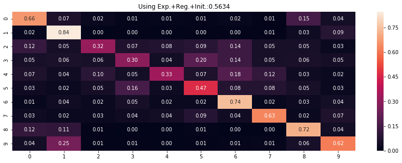

```python
summarize_net(model1_list[0], X_test, y_test, title_text='Using Exp.+Reg.+Init.:')
```

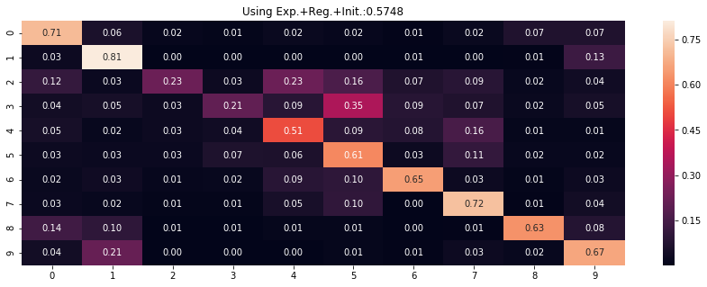

```python
summarize_net(model1_list[1], X_test, y_test, title_text='Using Exp.+Reg.+Init.:')
```

Visualize the performance of the training and validation sets per iteration in first model.

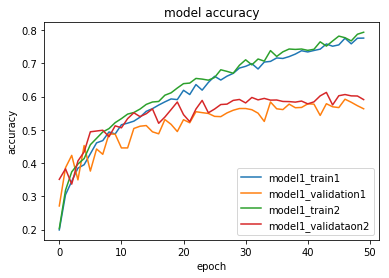

```python
plt.plot()
plt.plot(history1_list[0].history['acc'])
plt.plot(history1_list[0].history['val_acc'])
plt.plot(history1_list[1].history['acc'])
plt.plot(history1_list[1].history['val_acc'])
plt.title('model accuracy')
plt.ylabel('accuracy')
plt.xlabel('epoch')
plt.legend(['model1_train1', 'model1_validation1','model1_train2','model1_validataon2'], loc='best')
plt.show()
```

**Second model**

```python
def create2():
    cnn2 = Sequential()
    cnn2.add(Conv2D(filters=32,
                   input_shape = (img_wh,img_wh,3),
                   kernel_size=(3,3),
                   kernel_initializer='he_uniform',
                   kernel_regularizer=l2(l2_lambda),
                   padding='same',
                   activation='relu')) # more compact syntax
    cnn2.add(Conv2D(filters=32,
                   kernel_size=(3,3),
                   kernel_initializer='he_uniform',
                   kernel_regularizer=l2(l2_lambda),
                   padding='same',
                   activation='relu'))
    cnn2.add(MaxPooling2D(pool_size=(2, 2), data_format="channels_last"))

    cnn2.add(Conv2D(filters=64,
                   input_shape = (img_wh,img_wh,3),
                   kernel_size=(3,3),
                   kernel_initializer='he_uniform',
                   kernel_regularizer=l2(l2_lambda),
                   padding='same',
                   activation='relu')) # more compact syntax
    cnn2.add(Conv2D(filters=64,
                   kernel_size=(3,3),
                   kernel_initializer='he_uniform',
                   kernel_regularizer=l2(l2_lambda),
                   padding='same',
                   activation='relu'))
    cnn2.add(MaxPooling2D(pool_size=(2, 2), data_format="channels_last"))

    cnn2.add(Conv2D(filters=128,
                   kernel_size=(3,3),
                   kernel_initializer='he_uniform',
                   kernel_regularizer=l2(l2_lambda),
                   padding='same',
                   activation='relu'))
    cnn2.add(Conv2D(filters=128,
                   input_shape = (img_wh,img_wh,3),
                   kernel_size=(3,3),
                   kernel_initializer='he_uniform',
                   kernel_regularizer=l2(l2_lambda),
                   padding='same',
                   activation='relu')) # more compact syntax
    cnn2.add(MaxPooling2D(pool_size=(2, 2), data_format="channels_last"))


    # add one layer on flattened output
    cnn2.add(Dropout(0.25)) # add some dropout for regularization after conv layers
    cnn2.add(Flatten())
    cnn2.add(Dense(512,
                  activation='relu',
                  kernel_initializer='he_uniform',
                  kernel_regularizer=l2(l2_lambda)
           ))
    cnn2.add(Dropout(0.5)) # add some dropout for regularization, again!
    cnn2.add(Dense(NUM_CLASSES,
                  activation='softmax',
                  kernel_initializer='glorot_uniform',
                  kernel_regularizer=l2(l2_lambda)
                 ))

    # Let's train the model
    cnn2.compile(loss='categorical_crossentropy', # 'categorical_crossentropy' 'mean_squared_error'
                  optimizer='rmsprop', # 'adadelta' 'rmsprop'
                  metrics=['accuracy'])
    return cnn2
```

```python
model2_list=[]
history2_list= []
skf = StratifiedKFold(n_splits=2, shuffle=True)
for _, (train_indices, validation_indices) in enumerate(skf.split(X_train_s, y_train_s)):
    cnn2=create2()
    history2_list.append(cnn2.fit_generator(datagen.flow(X_train_s[train_indices], y_train_s_ohe[train_indices], batch_size=50),
                  steps_per_epoch=int(len(X_train_s[train_indices])/50), # how many generators to go through per epoch
                  epochs=50, verbose=1,
                  validation_data=(X_test[validation_indices],y_test_ohe[validation_indices])
                 ))
    model2_list.append(cnn2)
```

Visualize the performance of the training and validation sets per iteration in second model.

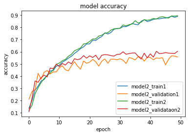

```python
plt.plot()
plt.plot(history2_list[0].history['acc'])
plt.plot(history2_list[0].history['val_acc'])
plt.plot(history2_list[1].history['acc'])
plt.plot(history2_list[1].history['val_acc'])
plt.title('model accuracy')
plt.ylabel('accuracy')
plt.xlabel('epoch')
plt.legend(['model2_train1', 'model2_validation1','model2_train2','model2_validataon2'], loc='best')
plt.show()
```

Here are the performance of second model under 2-fold cross validation in test set.

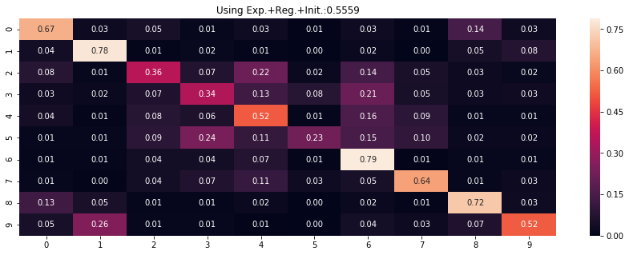

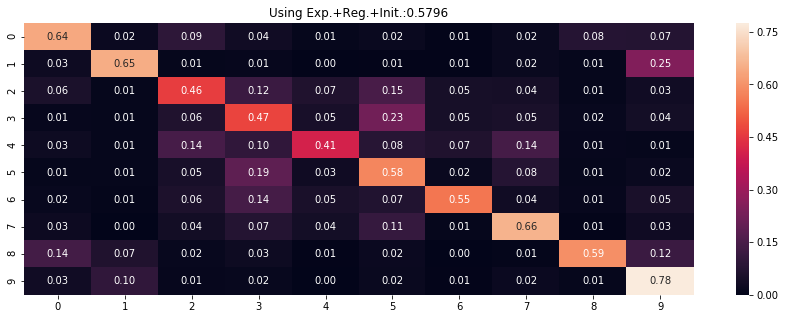

```python
summarize_net(model2_list[0], X_test, y_test, title_text='Using Exp.+Reg.+Init.:')
summarize_net(model2_list[1], X_test, y_test, title_text='Using Exp.+Reg.+Init.:')
```

**Third model**

```python
def create3():

    cnn1 = Sequential()
    cnn1.add(Conv2D(filters=32,
                   input_shape = (img_wh,img_wh,3),
                   kernel_size=(3,3),
                   kernel_initializer='he_uniform',
                   kernel_regularizer=l2(l2_lambda),
                   padding='same',
                   activation='relu')) # more compact syntax
    cnn1.add(MaxPooling2D(pool_size=(2, 2), data_format="channels_last"))
    cnn1.add(Conv2D(filters=32,
                   kernel_size=(3,3),
                   kernel_initializer='he_uniform',
                   kernel_regularizer=l2(l2_lambda),
                   padding='same',
                   activation='relu'))
    cnn1.add(MaxPooling2D(pool_size=(2, 2), data_format="channels_last"))


    # add one layer on flattened output
    cnn1.add(Dropout(0.25)) # add some dropout for regularization after conv layers
    cnn1.add(Flatten())
    cnn1.add(Dense(128,
                  activation='relu',
                  kernel_initializer='he_uniform',
                  kernel_regularizer=l2(l2_lambda)
           ))
    cnn1.add(Dropout(0.5)) # add some dropout for regularization, again!
    cnn1.add(Dense(512,
                  activation='relu',
                  kernel_initializer='he_uniform',
                  kernel_regularizer=l2(l2_lambda)
           ))
    cnn1.add(Dropout(0.5))
    cnn1.add(Dense(NUM_CLASSES,
                  activation='softmax',
                  kernel_initializer='glorot_uniform',
                  kernel_regularizer=l2(l2_lambda)
                 ))

    # Let's train the model
    cnn1.compile(loss='categorical_crossentropy', # 'categorical_crossentropy' 'mean_squared_error'
                  optimizer='rmsprop', # 'adadelta' 'rmsprop'
                  metrics=['accuracy'])
    return cnn1
```

```python
model3_list=[]
history3_list= []
skf = StratifiedKFold(n_splits=2, shuffle=True)
for _, (train_indices, validation_indices) in enumerate(skf.split(X_train_s, y_train_s)):
    cnn3=create3()
    history3_list.append(cnn3.fit_generator(datagen.flow(X_train_s[train_indices], y_train_s_ohe[train_indices], batch_size=50),
                  steps_per_epoch=int(len(X_train_s[train_indices])/50), # how many generators to go through per epoch
                  epochs=200, verbose=1,
                  validation_data=(X_test[validation_indices],y_test_ohe[validation_indices])
                 ))
    model3_list.append(cnn3)
```

Visualize the performance of the training and validation sets per iteration in third model.

[figure not shown]

```python
plt.plot()
plt.plot(history2_list[2].history['acc'])
plt.plot(history2_list[2].history['val_acc'])
plt.plot(history2_list[3].history['acc'])
plt.plot(history2_list[3].history['val_acc'])
plt.title('model accuracy')
plt.ylabel('accuracy')
plt.xlabel('epoch')
plt.legend(['model3_train1', 'model3_validation1','model3_train2','model3_validataon2'], loc='best')
plt.show()
```

Here are the performance of third model under 2-fold cross validation in test set.

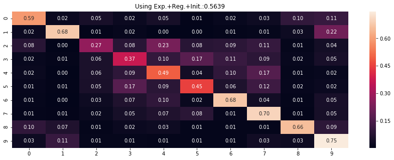

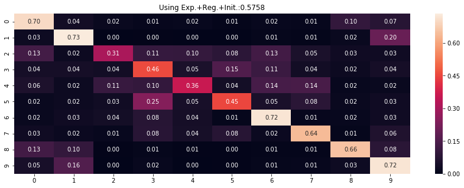

```python
summarize_net(model2_list[2], X_test, y_test, title_text='Using Exp.+Reg.+Init.:')
summarize_net(model2_list[3], X_test, y_test, title_text='Using Exp.+Reg.+Init.:')
```

## 2.3 Final Results of the CNNs

Here we made a comparision of our three tuning models.

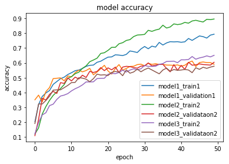

```python
plt.plot()
plt.plot(history1_list[1].history['acc'])
plt.plot(history1_list[1].history['val_acc'])
plt.plot(history2_list[1].history['acc'])
plt.plot(history2_list[1].history['val_acc'])
plt.plot(history2_list[3].history['acc'])
plt.plot(history2_list[3].history['val_acc'])
plt.title('model accuracy')
plt.ylabel('accuracy')
plt.xlabel('epoch')
plt.legend(['model1_train1', 'model1_validation1','model2_train2','model2_validataon2','model3_train2','model3_validataon2'], loc='best')
plt.show()
```

We can see that the performance in test set are very close, and the final accuracy is around 56~57%. And the best model we think is the second model. We compared our model with the great model on the internet and summarize two reasons. First is we only used a sample of CIFAR-10, and the more data model trained, the better performance will be. Second is the models on the internet are more complex and they have more convolutional layers.

## 2.4 Comparision to MLP

Here we choosed the second CNN model to compare to MLP model.

```python
from sklearn.neural_network import MLPClassifier
from sklearn.metrics import roc_curve
from sklearn.model_selection import cross_val_score
from sklearn.metrics import make_scorer, recall_score,accuracy_score
```

```python
X_r=[]
for i in X_train_s:
    X_r.append(i.reshape(32*32*3))
```

```python
mlp = MLPClassifier(hidden_layer_sizes=(50,10), max_iter=200, alpha=1e-4,
                    solver='adam', tol=1e-4, random_state=1)
cv = StratifiedKFold(n_splits=2)
my_scorer = make_scorer(accuracy_score)
per_fold_eval_criteria = cross_val_score(estimator=mlp,
                                    X=X_r,
                                    y=y_train_s,
                                    cv=cv,
                                    scoring=my_scorer
                                   )
```

Below we can find that the MLP works not well.

```
(0.25, 0.33439999999999998)
```

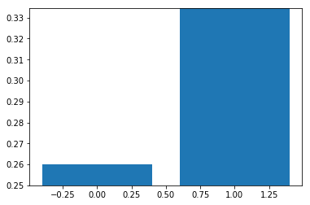

```python
plt.bar(range(len(per_fold_eval_criteria)),per_fold_eval_criteria)
plt.ylim([min(per_fold_eval_criteria)-0.01,max(per_fold_eval_criteria)])
```

```python
X_r_t=[]
for i in X_test:
    X_r_t.append(i.reshape(32*32*3))
```

```python
mlp.fit(X_r,y_train_s)
```

```
MLPClassifier(activation='relu', alpha=0.0001, batch_size='auto', beta_1=0.9,
       beta_2=0.999, early_stopping=False, epsilon=1e-08,
       hidden_layer_sizes=(50, 10), learning_rate='constant',
       learning_rate_init=0.001, max_iter=200, momentum=0.9,
       nesterovs_momentum=True, power_t=0.5, random_state=1, shuffle=True,
       solver='adam', tol=0.0001, validation_fraction=0.1, verbose=False,
       warm_start=False)
```

```python
y_pred = model2_list[1].predict_on_batch (X_test)
```

```
(10000, 10)
```

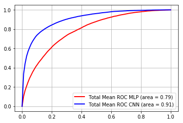

```python
from scipy import interp
mean_tpr = 0.0
mean_tpr1 = 0.0
mean_fpr1 = np.linspace(0, 1, 100)
mean_fpr = np.linspace(0, 1, 100)
all_tpr = []
perclass_mean_tpr = 0.0
perclass_mean_tpr1 = 0.0
roc_auc = 0
roc_auc1= 0
classes = np.unique(y_train)
# get the mean fpr and tpr, per class
probas = mlpm.predict_proba(X_r_t)
for j in classes:
    fpr, tpr, thresholds = roc_curve(y_test,
                                         probas[:, j],
                                         pos_label=j)
    fpr1,tpr1,thresholds1= roc_curve(y_test,
                                     y_pred[:, j],
                                     pos_label=j
                                    )
    perclass_mean_tpr += interp(mean_fpr, fpr, tpr)
    perclass_mean_tpr1 += interp(mean_fpr1, fpr1, tpr1)
    perclass_mean_tpr[0] = 0.0
    perclass_mean_tpr1[0] = 0.0

perclass_mean_tpr /= len(classes)
perclass_mean_tpr1 /= len(classes)
mean_tpr += perclass_mean_tpr
mean_auc = auc(mean_fpr, mean_tpr)
mean_tpr1 += perclass_mean_tpr1
mean_auc1= auc(mean_fpr1, mean_tpr1)
plt.plot(mean_fpr,perclass_mean_tpr,'k-',lw=2,label='Total Mean ROC MLP (area = %0.2f)'
                   % (mean_auc),color='red')
plt.plot(mean_fpr1,perclass_mean_tpr1,'k-',lw=2,label='Total Mean ROC CNN (area = %0.2f)'
                   % (mean_auc1),color='blue')
plt.legend(loc='best')
plt.grid()
```

The ROC figure shows that our CNN model is obviously better than the MLP model.

## Exceptional work

Use transfer learning to pre-train the weights of your initial layers of our CNN.

```python
from keras.applications.mobilenet import MobileNet
```

```python
VGG=VGG16(weights='imagenet')
```

```
Downloading data from https://github.com/fchollet/deep-learning-models/releases/download/v0.1/vgg16_weights_tf_dim_ordering_tf_kernels.h5
```

```python
VGG.summary()
```

[output not shown]

Compare the performance when using transfer learning to training from scratch in terms of classification performance.

```python
from scipy.misc import imresize
x_train_up = [imresize(x,size=(224,224,3), interp='nearest') for x in X_train_s]
x_train_up = np.stack(x_train_up,axis=0)
print(x_train_up.shape)

x_test_up = [imresize(x,size=(224,224,3), interp='nearest') for x in X_test]
x_test_up = np.stack(x_test_up,axis=0)
print(x_test_up.shape)
```

```
(5000, 224, 224, 3)
```

```
(10000, 224, 224, 3)
```

```python
x = VGG.output

# let's add a fully-connected layer
x = Dense(1024, activation='relu',kernel_initializer='he_uniform')(x)
# and a fully connected layer
predictions = Dense(NUM_CLASSES, activation='softmax', kernel_initializer='glorot_uniform')(x)

model = Model(inputs=VGG.input, outputs=predictions)

# freeze ResNet during training
for layer in VGG.layers:
    layer.trainable = False

model.compile(optimizer='rmsprop', loss='categorical_crossentropy',metrics=['accuracy'])

model.fit(x_train_up,y_train_s_ohe,epochs=5,batch_size=64,verbose=1)
```

```
<keras.callbacks.History at 0x185801df710>
```

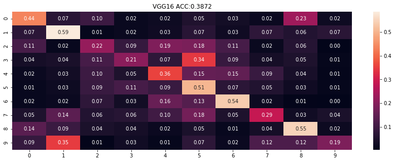

```python
summarize_net(model, x_test_up, y_test, title_text='VGG16 ACC:')
```

Because VGG16 is a complex model and it runs very slow, so we only made five epoches and the result is not very good. But we think it will be better after running much more epoches due to the trend. Here we realized that GPU is a good tool to help us make great work in the field of image.